# PROJETO FINAL ANALYTICS DESCRITIVA

Reidson Carvalho, Hugo Daher

2022-01-15

# Descrevendo a Base de Dados

A Base de dados utilizada neste relatório foi obtida a partir do link housesalesprediction. Este conjunto de dados contém preços de venda de casas coletados em King County, que inclui Seattle. Inclui casas vendidas entre maio de 2014 e maio de 2015. É um ótimo conjunto de dados para avaliar modelos de regressão simples.

## Descrição das variáveis contida na base de dados

1. id -> Número de identificação do imóvel na base de dados;
2. date -> Data da venda do imóvel;
3. price -> Preço de venda do imóvel;
4. bedrooms -> Número de quartos do imóvel;
5. bathrooms -> Número de banheiros do imóvel;
6. sqft_living -> Área construída do imóvel (calculada em pés**2);
7. sqft_lot -> Área total do imóvel (calculada em pés**2);
8. floors -> Número de andares do imóvel;
9. waterfront -> Indica se o imóvel está localizado a beira-mar;
10. view -> Quantidade de cômodos com vista para o mar;
11. condition -> Condição do imóvel (avaliado numa escala de 1 - 5);
12. grade -> Avaliação do imóvel (avaliado numa escala de 1 - 13);
13. sqft_above -> Área do sótão (calculada em pés**2);
14. sqft_basement -> Área do porão (calculada em pés**2);
15. yr_built -> Ano de construção;
16. yr_renovated -> **Significado Não Identificado**;
17. zipcode -> Código Postal;
18. lat -> Latitude;
19. long -> Longitude;
20. sqft_living15 -> **Significado Não Identificado**;
21. sqft_lot15 -> **Significado Não Identificado**;

# Carregando a Base de Dados

```r
# Carregando base de dados
houses <- read.csv("DADOS/kc_house_data.csv")
```

# Pré-processamento da base de dados

### Visualizando o cabeçalho do dataset

| id | date | price | bedrooms | bathrooms | sqft_living | sqft_lot | floors | waterfront | view | condition | grade | sqft_above | sqft_basement | yr_built | yr_renovated | zipcode | lat | long | sqft_living15 | sqft_lot15 |
| --- | --- | --- | --- | --- | --- | --- | --- | --- | --- | --- | --- | --- | --- | --- | --- | --- | --- | --- | --- | --- |
| 7129300520 | 20141013T000000 | 221900 | 3 | 1.00 | 1180 | 5650 | 1 | 0 | 0 | 3 | 7 | 1180 | 0 | 1955 | 0 | 98178 | 47.5112 | -122.257 | 1340 | 5650 |
| 6414100192 | 20141209T000000 | 538000 | 3 | 2.25 | 2570 | 7242 | 2 | 0 | 0 | 3 | 7 | 2170 | 400 | 1951 | 1991 | 98125 | 47.7210 | -122.319 | 1690 | 7639 |
| 5631500400 | 20150225T000000 | 180000 | 2 | 1.00 | 770 | 10000 | 1 | 0 | 0 | 3 | 6 | 770 | 0 | 1933 | 0 | 98028 | 47.7379 | -122.233 | 2720 | 8062 |
| 2487200875 | 20141209T000000 | 604000 | 4 | 3.00 | 1960 | 5000 | 1 | 0 | 0 | 5 | 7 | 1050 | 910 | 1965 | 0 | 98136 | 47.5208 | -122.393 | 1360 | 5000 |
| 1954400510 | 20150218T000000 | 510000 | 3 | 2.00 | 1680 | 8080 | 1 | 0 | 0 | 3 | 8 | 1680 | 0 | 1987 | 0 | 98074 | 47.6168 | -122.045 | 1800 | 7503 |
| 7237550310 | 20140512T000000 | 1225000 | 4 | 4.50 | 5420 | 101930 | 1 | 0 | 0 | 3 | 11 | 3890 | 1530 | 2001 | 0 | 98053 | 47.6561 | -122.005 | 4760 | 101930 |

### Inspecionando base de dados - Informações Gerais

> Tamanho da base de dados

```
## [1] 21613    21
```

> Visão geral da base de dados

```
## 'data.frame':    21613 obs. of  21 variables:
##  $ id           : num  7.13e+09 6.41e+09 5.63e+09 2.49e+09 1.95e+09 ...
##  $ date         : chr  "20141013T000000" "20141209T000000" "20150225T000000" "20141209T000000" ...
##  $ price        : num  221900 538000 180000 604000 510000 ...
##  $ bedrooms     : int  3 3 2 4 3 4 3 3 3 3 ...
##  $ bathrooms    : num  1 2.25 1 3 2 4.5 2.25 1.5 1 2.5 ...
##  $ sqft_living  : int  1180 2570 770 1960 1680 5420 1715 1060 1780 1890 ...
##  $ sqft_lot     : int  5650 7242 10000 5000 8080 101930 6819 9711 7470 6560 ...
##  $ floors       : num  1 2 1 1 1 1 2 1 1 2 ...
##  $ waterfront   : int  0 0 0 0 0 0 0 0 0 0 ...
##  $ view         : int  0 0 0 0 0 0 0 0 0 0 ...
##  $ condition    : int  3 3 3 5 3 3 3 3 3 3 ...
##  $ grade        : int  7 7 6 7 8 11 7 7 7 7 ...
##  $ sqft_above   : int  1180 2170 770 1050 1680 3890 1715 1060 1050 1890 ...
##  $ sqft_basement: int  0 400 0 910 0 1530 0 0 730 0 ...
##  $ yr_built     : int  1955 1951 1933 1965 1987 2001 1995 1963 1960 2003 ...
##  $ yr_renovated : int  0 1991 0 0 0 0 0 0 0 0 ...
##  $ zipcode      : int  98178 98125 98028 98136 98074 98053 98003 98198 98146 98038 ...
##  $ lat          : num  47.5 47.7 47.7 47.5 47.6 ...
##  $ long         : num  -122 -122 -122 -122 -122 ...
##  $ sqft_living15: int  1340 1690 2720 1360 1800 4760 2238 1650 1780 2390 ...
##  $ sqft_lot15   : int  5650 7639 8062 5000 7503 101930 6819 9711 8113 7570 ...
```

> Verificando a existência de valores nulos

```
## [1] 0
```

**Esta base de dados não possui valores nulos**

# Tratamento dos Dados

### Eliminando Colunas

Por não acrescentarem nenhuma informação útil à análise, as coluna “id” e “zipcode” serão eliminadas da base de dados

```r
# Eliminando coluna "id"
houses$id <- NULL
houses$zipcode <- NULL
```

### Modificando os títulos das colunas

```r
# Modificando os títulos das colunas
# Por não compreender o significado das colunas "yr_renovated",
# "sqft_living15" e "sqft_lot15" o nome destas colunas não foi modificado.
names(houses) <- c("Data", "Preco", "Num_Quartos", "Num_Banheiros", "Area_Construida",
                   "Area_Total", "Num_Andares", "Beira_Mar", "Vista_Mar", "Condicao",
                   "Avaliacao", "Area_Sotao", "Area_Porao", "Ano_Contrucao",
                   "yr_renovated", "Latitude", "Longitude",
                   "sqft_living15", "sqft_lot15")
```

### Ajustando o formato da coluna “Data”

```r
# Ajustando a coluna Data para o formato correto
houses$Data <- substr(houses$Data, 1, 8)
houses$Data <- ymd(houses$Data)
```

### Visualizando o dataset após as modificações

> Visão geral da base de dados

```
## 'data.frame':    21613 obs. of  19 variables:
##  $ Data           : Date, format: "2014-10-13" "2014-12-09" ...
##  $ Preco          : num  221900 538000 180000 604000 510000 ...
##  $ Num_Quartos    : int  3 3 2 4 3 4 3 3 3 3 ...
##  $ Num_Banheiros  : num  1 2.25 1 3 2 4.5 2.25 1.5 1 2.5 ...
##  $ Area_Construida: int  1180 2570 770 1960 1680 5420 1715 1060 1780 1890 ...
##  $ Area_Total     : int  5650 7242 10000 5000 8080 101930 6819 9711 7470 6560 ...
##  $ Num_Andares    : num  1 2 1 1 1 1 2 1 1 2 ...
##  $ Beira_Mar      : int  0 0 0 0 0 0 0 0 0 0 ...
##  $ Vista_Mar      : int  0 0 0 0 0 0 0 0 0 0 ...
##  $ Condicao       : int  3 3 3 5 3 3 3 3 3 3 ...
##  $ Avaliacao      : int  7 7 6 7 8 11 7 7 7 7 ...
##  $ Area_Sotao     : int  1180 2170 770 1050 1680 3890 1715 1060 1050 1890 ...
##  $ Area_Porao     : int  0 400 0 910 0 1530 0 0 730 0 ...
##  $ Ano_Contrucao  : int  1955 1951 1933 1965 1987 2001 1995 1963 1960 2003 ...
##  $ yr_renovated   : int  0 1991 0 0 0 0 0 0 0 0 ...
##  $ Latitude       : num  47.5 47.7 47.7 47.5 47.6 ...
##  $ Longitude      : num  -122 -122 -122 -122 -122 ...
##  $ sqft_living15  : int  1340 1690 2720 1360 1800 4760 2238 1650 1780 2390 ...
##  $ sqft_lot15     : int  5650 7639 8062 5000 7503 101930 6819 9711 8113 7570 ...
```

> Tamanho da base de dados após as modificações

```
## [1] 21613    19
```

# Avaliando a Relação do Preço com as Variáveis Numéricas

### Descrevendo variáveis numéricas

```
##       Data                Preco          Num_Quartos     Num_Banheiros
##  Min.   :2014-05-02   Min.   :  75000   Min.   : 0.000   Min.   :0.000
##  1st Qu.:2014-07-22   1st Qu.: 321950   1st Qu.: 3.000   1st Qu.:1.750
##  Median :2014-10-16   Median : 450000   Median : 3.000   Median :2.250
##  Mean   :2014-10-29   Mean   : 540088   Mean   : 3.371   Mean   :2.115
##  3rd Qu.:2015-02-17   3rd Qu.: 645000   3rd Qu.: 4.000   3rd Qu.:2.500
##  Max.   :2015-05-27   Max.   :7700000   Max.   :33.000   Max.   :8.000
##  Area_Construida   Area_Total       Num_Andares      Beira_Mar
##  Min.   :  290   Min.   :    520   Min.   :1.000   Min.   :0.000000
##  1st Qu.: 1427   1st Qu.:   5040   1st Qu.:1.000   1st Qu.:0.000000
##  Median : 1910   Median :   7618   Median :1.500   Median :0.000000
##  Mean   : 2080   Mean   :  15107   Mean   :1.494   Mean   :0.007542
##  3rd Qu.: 2550   3rd Qu.:  10688   3rd Qu.:2.000   3rd Qu.:0.000000
##  Max.   :13540   Max.   :1651359   Max.   :3.500   Max.   :1.000000
##    Vista_Mar         Condicao       Avaliacao        Area_Sotao
##  Min.   :0.0000   Min.   :1.000   Min.   : 1.000   Min.   : 290
##  1st Qu.:0.0000   1st Qu.:3.000   1st Qu.: 7.000   1st Qu.:1190
##  Median :0.0000   Median :3.000   Median : 7.000   Median :1560
##  Mean   :0.2343   Mean   :3.409   Mean   : 7.657   Mean   :1788
##  3rd Qu.:0.0000   3rd Qu.:4.000   3rd Qu.: 8.000   3rd Qu.:2210
##  Max.   :4.0000   Max.   :5.000   Max.   :13.000   Max.   :9410
##    Area_Porao     Ano_Contrucao   yr_renovated       Latitude
##  Min.   :   0.0   Min.   :1900   Min.   :   0.0   Min.   :47.16
##  1st Qu.:   0.0   1st Qu.:1951   1st Qu.:   0.0   1st Qu.:47.47
##  Median :   0.0   Median :1975   Median :   0.0   Median :47.57
##  Mean   : 291.5   Mean   :1971   Mean   :  84.4   Mean   :47.56
##  3rd Qu.: 560.0   3rd Qu.:1997   3rd Qu.:   0.0   3rd Qu.:47.68
##  Max.   :4820.0   Max.   :2015   Max.   :2015.0   Max.   :47.78
##    Longitude      sqft_living15    sqft_lot15
##  Min.   :-122.5   Min.   : 399   Min.   :   651
##  1st Qu.:-122.3   1st Qu.:1490   1st Qu.:  5100
##  Median :-122.2   Median :1840   Median :  7620
##  Mean   :-122.2   Mean   :1987   Mean   : 12768
##  3rd Qu.:-122.1   3rd Qu.:2360   3rd Qu.: 10083
##  Max.   :-121.3   Max.   :6210   Max.   :871200
```

### Visualizando dados numéricos

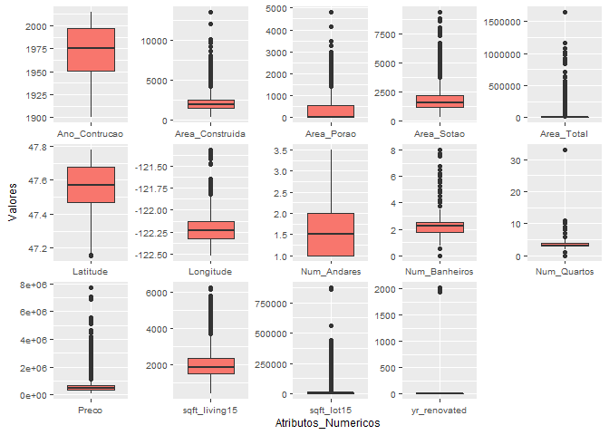

### Matriz de correlação

Uma matriz de correlação será criada para que se possa visualizar as correlações entre todas as variáveis numéricas.

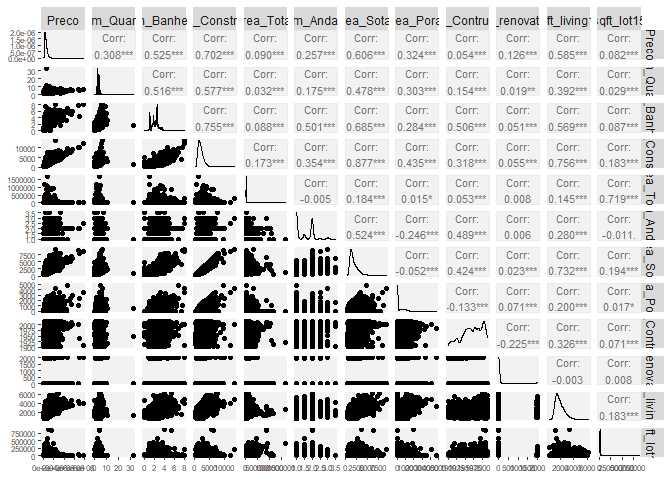

### Mapa de calor para matriz de correlação

Para que se possa visualizar melhor as correlações entre as variáveis numéricas, será criado um mapa de calor para a matriz de correlações

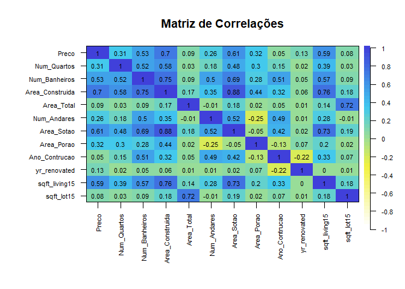

É possivel visualizar que as variáveis com as quais o preço do imóvel tem uma boa correlação são:

1. Número de banheiros;
2. Área Construída;
3. Área do Sotão;

# Avaliando a Relação do Preço do Imóvel com as Variáveis Categóricas

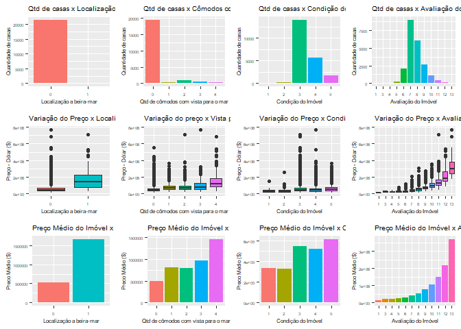

# Gerando Mapas

### Visualização da região onde os dados foram coletados

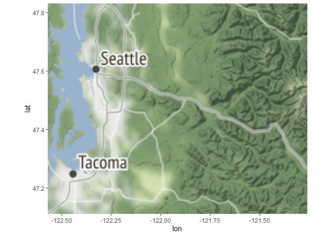

### Visualizando os imóveis na região de coleta

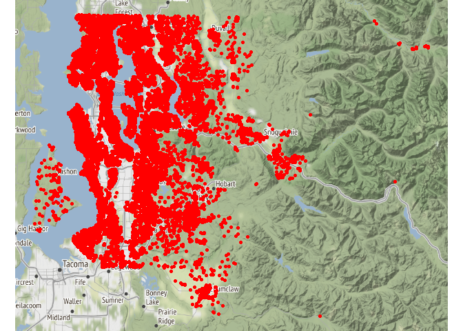